# Kernel Distance Metric Learning with kdml

Daniel Krasnov

# Overview

Distance-based methods need a useful definition of dissimilarity. That is particularly difficult when a data frame mixes continuous measurements, nominal factors, and ordered factors. Kernel distance metric learning (KDML) assigns a type-compatible kernel and bandwidth to each feature. The bandwidth controls how strongly differences in that feature affect the result and can therefore shrink irrelevant features toward uniform similarity.

For observations $\mathbf{x}_i$ and $\mathbf{x}_j$, `kdml` supports two similarities. DKPS uses a product over continuous kernels and sums the nominal and ordinal kernels; DKSS sums all feature kernels. Either similarity $s$ is converted to a squared kernel distance by

$$d^2(\mathbf{x}_i,\mathbf{x}_j)
= s(\mathbf{x}_i,\mathbf{x}_i)
+ s(\mathbf{x}_j,\mathbf{x}_j)
- 2s(\mathbf{x}_i,\mathbf{x}_j).$$

The traditional estimator chooses bandwidths by maximum similarity cross-validation (MSCV). The MCMC interface treats the MSCV score as a loss within a generalized Bayesian update, allowing uncertainty in both bandwidths and feature-specific kernel choices. This vignette uses deliberately small settings so it rebuilds quickly and reproducibly on the CPU. Increase the warmup and retained draws for substantive analysis.

# Installation and optional CUDA support

The standard source and binary packages always provide the CPU backend.

```r
install.packages("kdml")
library(kdml)
```

CUDA support is optional and is never required by package examples or vignettes. A source installation can request it when a compatible NVIDIA GPU, CUDA toolkit, and host compiler are available.

```r
Sys.setenv(KDML_ENABLE_CUDA = "true")
install.packages("kdml", type = "source", INSTALL_opts = "--preclean")
```

The availability check is safe on CPU-only systems.

```r
cuda_info()[c("compiled", "available", "device_count")]
```

```
#> $compiled
#> [1] FALSE
#>
#> $available
#> [1] FALSE
#>
#> $device_count
#> [1] 0
```

# A small mixed-type example

`confactord()` generates continuous, nominal, and ordinal features together with the true two-group membership. We use 36 observations and one feature of each type.

```r
set.seed(100)
simulated <- confactord(
  n = 36,
  popProb = c(0.5, 0.5),
  numMixVar = c(1, 1, 1),
  numMixVarOl = c(1, 1, 1),
  olVarType = c(0.20, 0.20, 0.20),
  catLevels = c(3, 4)
)

dat <- simulated$data
names(dat) <- c("continuous", "nominal", "ordinal")
true_group <- factor(simulated$class)
str(dat)
```

```
#> 'data.frame':    36 obs. of  3 variables:
#>  $ continuous: num  4.593 -1.381 4.733 -0.931 4.156 ...
#>  $ nominal   : Factor w/ 2 levels "1","2": 1 1 1 1 1 1 1 1 1 1 ...
#>  $ ordinal   : Ord.factor w/ 4 levels "1"<"2"<"3"<"4": 3 1 2 1 4 1 1 3 3 2 ...
```

If bandwidths have already been chosen, `dkps()` and `dkss()` calculate a distance directly. Numeric bandwidths follow data-frame column order. Here the continuous bandwidth is on the data scale, while the categorical bandwidths lie strictly between zero and one.

```r
fixed_bandwidths <- c(stats::sd(dat$continuous), 0.25, 0.25)
fixed <- dkps(dat, bw = fixed_bandwidths)
fixed$distances[1:4, 1:4]
```

```
#>           [,1]         [,2]      [,3]         [,4]
#> [1,] 0.0000000 0.5046486656 0.4100976 0.5008134376
#> [2,] 0.5046487 0.0000000000 0.4618125 0.0005199902
#> [3,] 0.4100976 0.4618124999 0.0000000 0.4581172893
#> [4,] 0.5008134 0.0005199902 0.4581173 0.0000000000
```

For a full analysis, bandwidth point estimates can instead be obtained with `mscv.dkps()` or `mscv.dkss()`. Those optimization routines are not run here because their runtime depends strongly on the data and requested restarts.

```r
set.seed(100)
mscv_fit <- mscv.dkps(dat, nstart = 3)
distance_from_mscv <- dkps(dat, bw = mscv_fit$bw[, 1])
```

# Sampling kernels and bandwidths

The convenience functions `mcmc.dkps()` and `mcmc.dkss()` select the distance definition. Multiple chains are important for convergence diagnostics. The small run below exercises the complete workflow, but is much shorter than a run intended for inference.

```r
set.seed(101)
fit <- mcmc.dkps(
  dat,
  chains = 2,
  chain_threads = 1,
  warmup = 25,
  draws = 40,
  thin = 1,
  backend = "cpu",
  progress = FALSE
)
fit
```

```
#> KDML MCMC fit
#>   distance: DKPS
#>   backend: cpu
#>   features: 3
#>   chains: 2, chain threads: 1, retained draws per chain: 40
#>   retained MAP: draw 3, chain 1
#>   MAP log target: -11.35
#>   MAP MSCV score: 0.278574
#>   MAP kernels:
#>  continuous     nominal     ordinal
#> "c_tricube"  "u_aitken" "o_habbema"
```

The fit stores transformed bandwidths (`theta`), natural-scale bandwidths, kernel names and codes, MSCV scores, log targets, proposal diagnostics, and a draws array that follows the conventions of the `posterior` package. The `map` component is the retained state with the largest sampled log target.

```r
fit$map$kernel
```

```
#>  continuous     nominal     ordinal
#> "c_tricube"  "u_aitken" "o_habbema"
```

```r
fit$map$bandwidth
```

```
#> continuous    nominal    ordinal
#>  6.6245941  0.4528164  0.5090300
```

```r
dim(posterior::as_draws_array(fit))
```

```
#> [1] 40  2  8
```

`dkps(fit)` reconstructs distances from the retained MAP state for a DKPS fit; `dkss(fit)` provides the corresponding operation for a DKSS fit.

```r
mcmc_distance <- dkps(fit)
mcmc_distance$distances[1:4, 1:4]
```

```
#>           1            2         3            4
#> 1 0.0000000 6.332086e-01 0.2930588 6.289149e-01
#> 2 0.6332086 0.000000e+00 0.3701590 7.292709e-05
#> 3 0.2930588 3.701590e-01 0.0000000 3.668170e-01
#> 4 0.6289149 7.292709e-05 0.3668170 0.000000e+00
```

# Diagnostics

`summary()` combines transformed-bandwidth diagnostics with kernel occupancy, kernel transitions, score summaries, and post-warmup acceptance rates. Short demonstration chains will commonly trigger low-ESS or $\widehat R$ warnings; those warnings are a reason to run longer chains before interpreting a real analysis.

```r
fit_summary <- summary(fit, min_ess_per_chain = 10)
fit_summary$theta
```

```
#>      feature          variable        mean       sd     rhat ess_bulk ess_tail
#> 1 continuous theta[continuous] -0.42728307 1.694451 2.210999 3.237532 20.59342
#> 2    nominal    theta[nominal] -0.96657210 1.075180 1.191324 8.060816 17.04036
#> 3    ordinal    theta[ordinal] -0.07423429 2.354820 2.531757 2.985366 22.05456
#>   mcse_mean
#> 1 1.0182977
#> 2 0.3810887
#> 3 1.4398421
```

```r
fit_summary$convergence
```

```
#> $ok
#> [1] FALSE
#>
#> $warnings
#> [1] "R-hat exceeds 1.01 for: continuous, nominal, ordinal."
#> [2] "Bulk or tail ESS is below 20 (10 per chain) for: continuous, nominal, ordinal."
#>
#> $thresholds
#> $thresholds$rhat
#> [1] 1.01
#>
#> $thresholds$min_ess_per_chain
#> [1] 10
```

```r
fit_summary$kernel_occupancy
```

```
#>       feature  chain            kernel count proportion
#> 1  continuous chain1        c_gaussian     4      0.100
#> 2  continuous chain1    c_epanechnikov     7      0.175
#> 3  continuous chain1         c_uniform     2      0.050
#> 4  continuous chain1        c_triangle     1      0.025
#> 5  continuous chain1        c_biweight     3      0.075
#> 6  continuous chain1       c_triweight     2      0.050
#> 7  continuous chain1         c_tricube     3      0.075
#> 8  continuous chain1          c_cosine     2      0.050
#> 9  continuous chain1        c_logistic     5      0.125
#> 10 continuous chain1         c_sigmoid     6      0.150
#> 11 continuous chain1       c_silverman     5      0.125
#> 12 continuous chain2        c_gaussian     4      0.100
#> 13 continuous chain2    c_epanechnikov     4      0.100
#> 14 continuous chain2         c_uniform     3      0.075
```

[output cut: 22 more lines]

Trace and kernel-occupancy plots provide complementary views of continuous and discrete mixing.

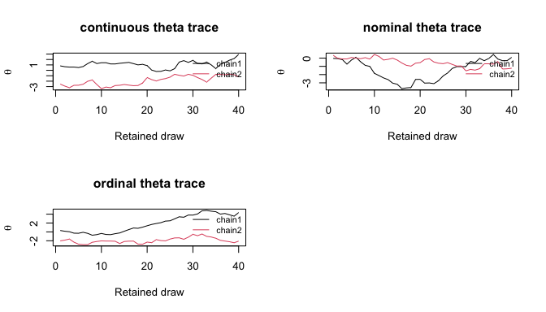

```r
plot(fit, type = "trace")
```

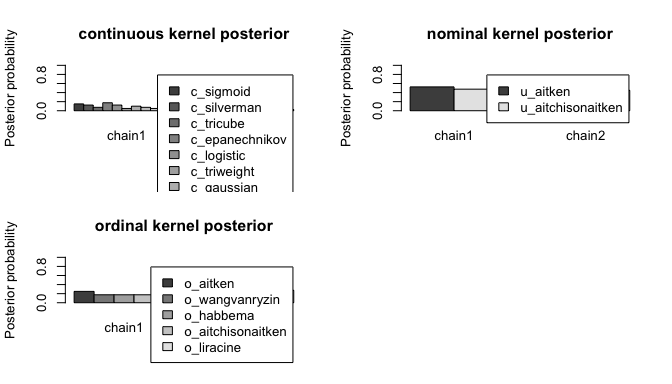

```r
plot(fit, type = "kernel")
```

Other plot types are `"acf"`, `"diagnostics"`, `"score"`, `"bandwidth"`, and `"acceptance"`. Features and chains can be selected by name or index.

# Using a learned distance

Because the returned values are squared kernel distances, take a square root before supplying them to an algorithm that expects ordinary distances. As a small illustration, we compare Ward clustering from the fixed state and the sampled MAP state.

```r
fixed_tree <- hclust(as.dist(sqrt(pmax(fixed$distances, 0))), method = "ward.D2")
mcmc_tree <- hclust(
  as.dist(sqrt(pmax(mcmc_distance$distances, 0))),
  method = "ward.D2"
)

fixed_cluster <- cutree(fixed_tree, k = 2)
mcmc_cluster <- cutree(mcmc_tree, k = 2)
table(true_group, fixed_cluster)
```

```
#>           fixed_cluster
#> true_group  1  2
#>          1 18  0
#>          2 11  7
```

```r
table(true_group, mcmc_cluster)
```

```
#>           mcmc_cluster
#> true_group  1  2
#>          1  1 17
#>          2 17  1
```

These compact results illustrate the mechanics, not an assessment of sampler convergence or clustering performance. A real analysis should use more draws, inspect all relevant diagnostics, and assess the stability of conclusions across plausible retained states.

# References

Bissiri, P. G., Holmes, C. C., and Walker, S. G. (2016). A general framework for updating belief distributions. *Journal of the Royal Statistical Society: Series B*, 78(5), 1103–1130. https://doi.org/10.1111/rssb.12158.

Ghashti, J. S. (2024). *Similarity Maximization and Shrinkage Approach in Kernel Metric Learning for Clustering Mixed-Type Data*. PhD thesis, University of British Columbia. https://doi.org/10.14288/1.0443975.

Ghashti, J. S. and Thompson, J. R. J. (2025). Mixed-type distance shrinkage and selection for clustering via kernel metric learning. *Journal of Classification*, 42, 311–334. https://doi.org/10.1007/s00357-024-09493-z.